# Convert plots to grob and ggplot objects

Guangchuang Yu  
School of Basic Medical Sciences, Southern Medical University

2026-10-12

`ggplotify` converts a plot into a `grob` or a `ggplot` object. Two functions do the work, `as.grob()` and `as.ggplot()`, and both accept four kinds of input:

- a plot call, written as a formula (`~barplot(1:10)`) or an `expression`
- a function that draws to a graphics device when it is called
- a graphic object produced by another package, such as a `ggplot` or `trellis`
- a plot captured by `grDevices::recordPlot()`

The output is an ordinary `grid` object, so a plot drawn by base graphics can be arranged, aligned, annotated and inset like a `ggplot2` plot. The classes `as.grob()` dispatches on are listed at the end of this document.

## Plot calls

```r
library(ggplot2)
library(ggplotify)

p1 <- as.grob(~barplot(1:10, main = "formula"))
p2 <- as.grob(expression(barplot(11:20, main = "expression")))
p3 <- as.grob(function() barplot(21:30, main = "function"))
```

`as.grob()` replays the call on a graphics device and captures the result with `gridGraphics::grid.echo()`. A formula or an expression is evaluated in the environment `as.grob()` was called from, which is the global environment at the top level. A variable that is local to the function doing the conversion is therefore not visible, and needs `envir`:

```r
as.grob(~barplot(n), envir = environment())
```

A function is simply called, which makes it the most general form: any code that draws to a device works, and it carries its own environment with it.

## Graphic objects

A plot that already exists as an object needs no call to be written for it, and `as.grob()` takes it directly. Some classes are converted straight from the object, others are drawn once into a device and captured from there.

```r
library(lattice)

p4 <- as.grob(densityplot(~mpg | cyl, data = mtcars))
p5 <- as.grob(ggplot(mtcars, aes(wt, mpg)) + geom_point())
```

`p4` is a `trellis` object returned by `lattice` and `p5` is a `ggplot2` plot. Converting a `ggplot` object gives back the `gtable` built by `ggplot2::ggplotGrob()`, and a `grob` is returned unchanged.

## Recorded plots

`grDevices::recordPlot()` stores the display list of the current device. On most file devices that list is not kept unless it is switched on, so `dev.control(displaylist = "enable")` has to come before the plot is drawn.

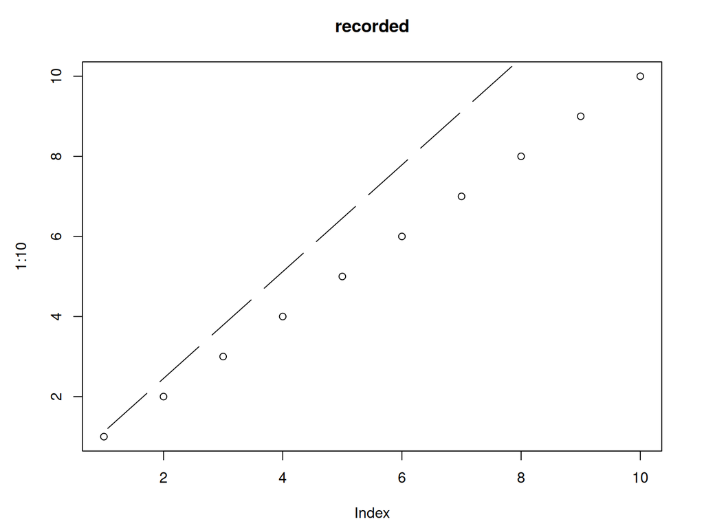

```r
pdf(tempfile(fileext = ".pdf"))
dev.control(displaylist = "enable")
plot(1:10, type = "b", main = "recorded")
recording <- recordPlot()
invisible(dev.off())

as.ggplot(recording)
```

This makes it possible to draw a plot once, keep the recording, and place it in a composed figure later. A recording of a device whose display list stayed inhibited holds no graphics, and `as.grob()` says so rather than returning an empty grob.

```r
pdf(tempfile(fileext = ".pdf"))
plot(1:10)
empty <- recordPlot()
invisible(dev.off())

try(as.grob(empty))
```

```
Error in as.grob.recordedplot(empty) :
  No graphics were captured from the recorded plot. Enable the display list, via grDevices::dev.control(displaylist = "enable"), before drawing the plot that is passed to grDevices::recordPlot().
```

Replaying a recording needs the same R version, the same type of graphics device and the packages that drew the original plot, and it is only guaranteed within the session that called `recordPlot()`.

## Drawing with grid

A converted plot is a `grob`, so `grid.draw()` renders it and `pushViewport()` places it inside another plot.

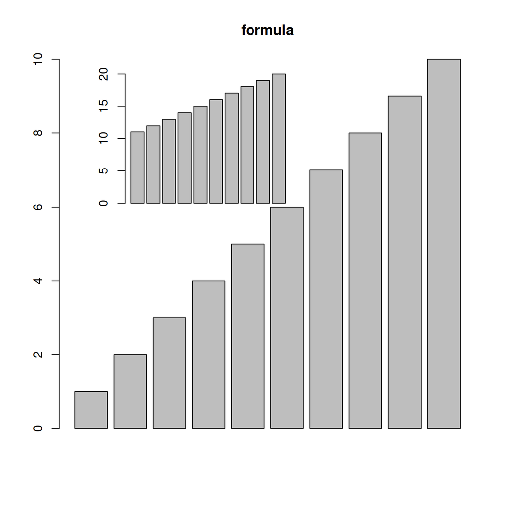

```r
library(grid)

grid.newpage()
grid.draw(p1)
vp <- viewport(x = .4, y = .72, width = .4, height = .35)
pushViewport(vp)
grid.draw(p2)
upViewport()
```

`grid.draw()` has methods for the three call forms as well, so no conversion is needed when the only goal is to draw a plot.

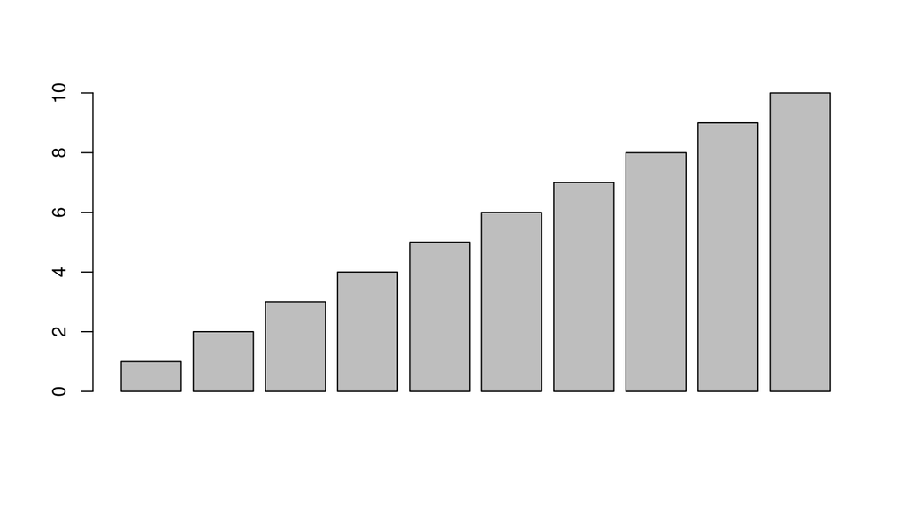

```r
grid.draw(~barplot(1:10))
```

## Converting to a ggplot object

`as.ggplot()` puts the converted grob into a `ggplot2` plot with a blank panel and `theme_void()`. Layers, scales and themes can then be added on top of the original figure.

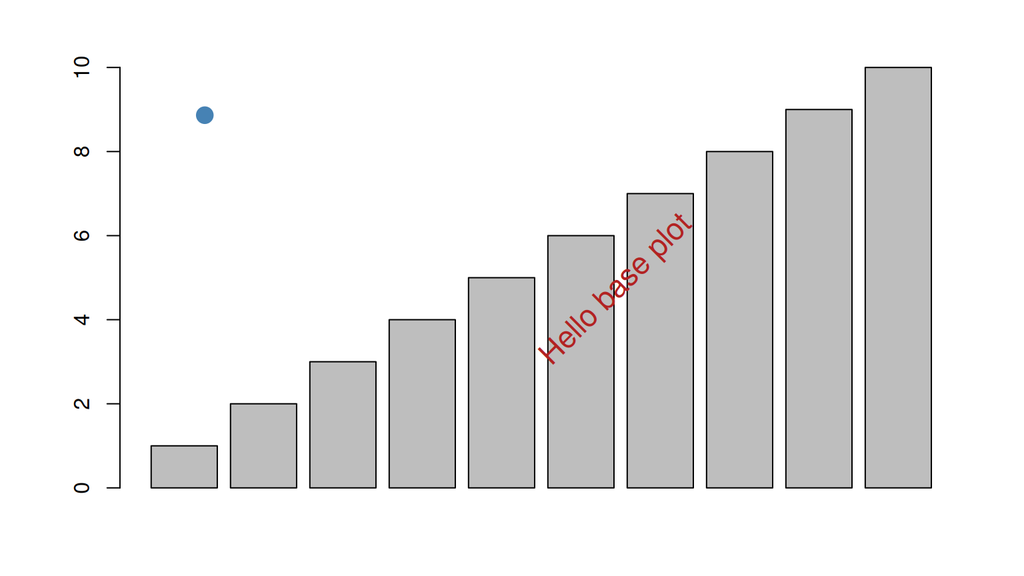

```r
as.ggplot(~barplot(1:10)) +
    annotate("text", x = .6, y = .5, label = "Hello base plot",
             size = 6, color = "firebrick", angle = 45) +
    annotate("point", x = .2, y = .8, color = "steelblue", size = 4)
```

`scale`, `hjust` and `vjust` place the original figure in a rectangle, and `angle` rotates it. The rectangle runs from `1 - scale` to `scale` on both axes and is shifted by `hjust` and `vjust`, so `scale = 1` fills the panel and `scale = .9` leaves a tenth of it at every edge. The figure is clipped to that rectangle rather than shrunk into it, which is why a small `scale` cuts titles and axis labels off instead of drawing them smaller. In practice `scale` stays close to 1.

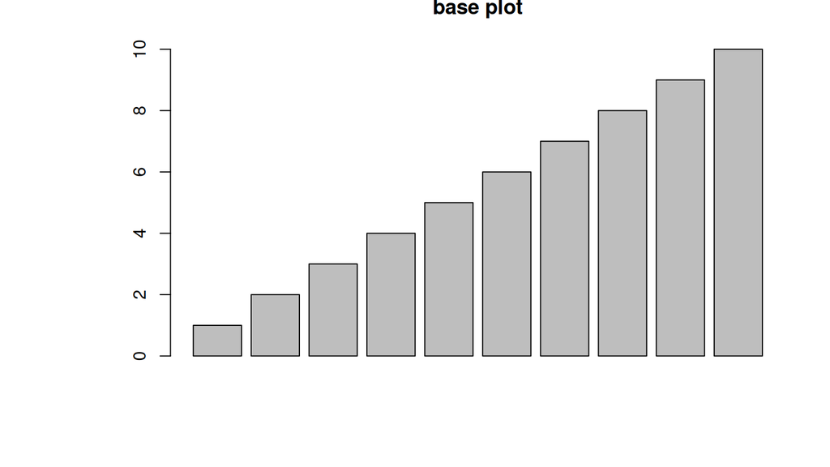

```r
as.ggplot(~barplot(1:10, main = "base plot"), scale = .95, hjust = .05, vjust = .05)
```

`angle` rotates the figure. A rotated figure goes through a viewport rather than the rectangle above, and `scale` is the width of that viewport.

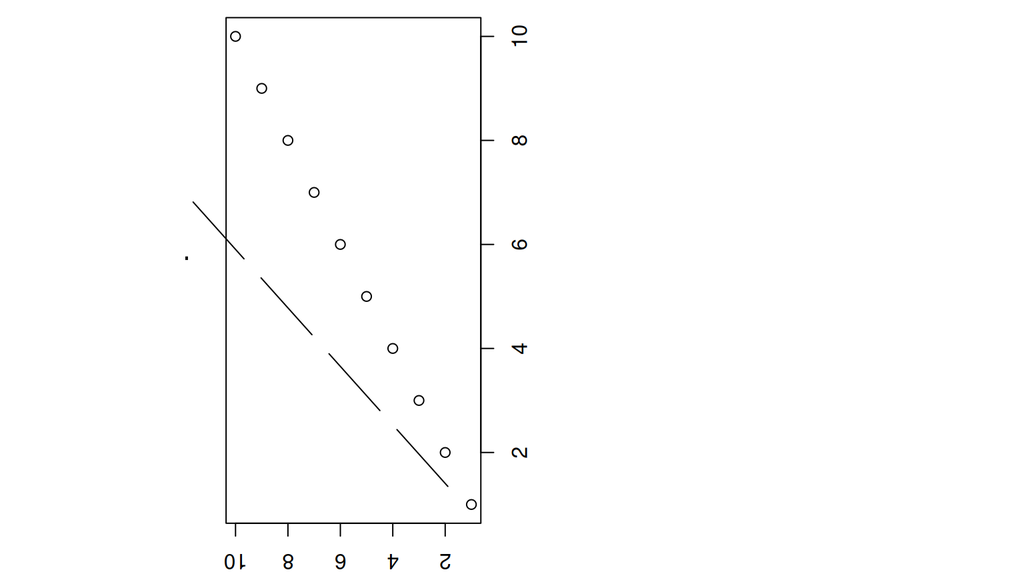

```r
as.ggplot(~plot(1:10, type = "b", main = "base plot"), angle = 90,
          scale = .6, hjust = -.15)
```

Grid cannot clip to a viewport that is rotated by something other than a multiple of 90 degrees, so a non-right angle emits the warning `cannot clip to rotated viewport` once for every clipped grob. The figure is still drawn.

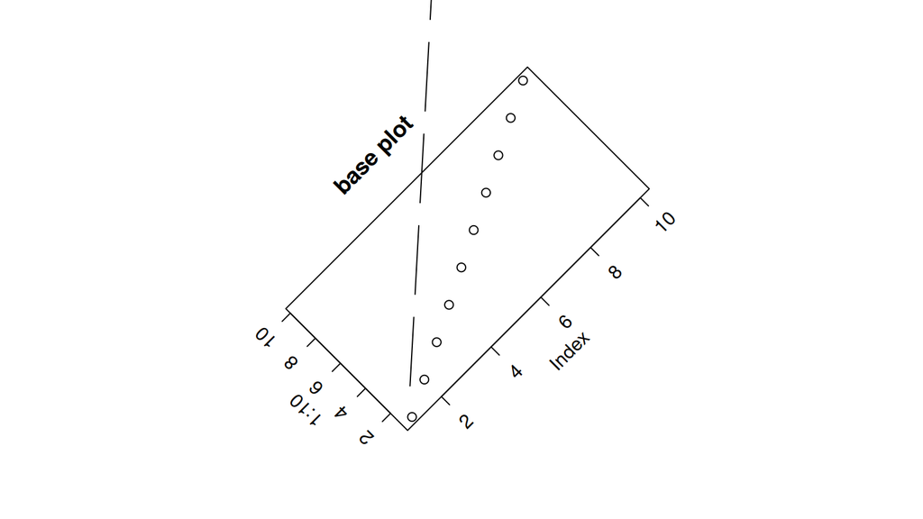

```r
as.ggplot(~plot(1:10, type = "b", main = "base plot"), angle = 45, scale = .45)
```

A plot drawn by a `grid` based package converts the same way. Capture it with `grid2grob()` rather than a formula: a formula is replayed by `gridGraphics::grid.echo()`, which does not understand the grid drawing operations of the original plot and emits one `unsupported operation on the graphics display list` warning for every operation it cannot replay. `vcd::mosaic` here, with a `ggplot2` annotation added on top of it.

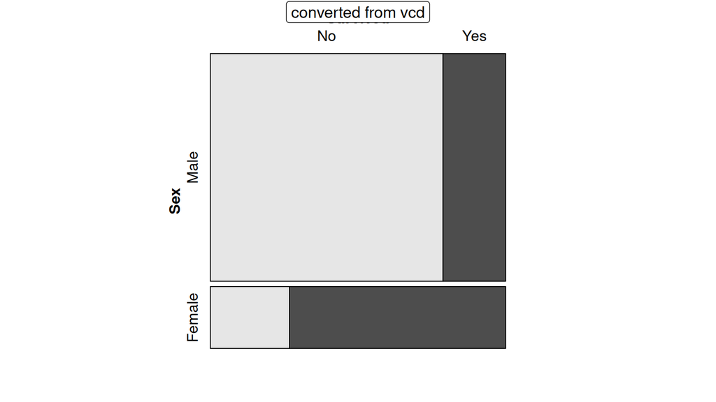

```r
library(vcd)
data(Titanic)

as.ggplot(grid2grob(mosaic(Survived ~ Sex, data = as.data.frame(Titanic)))) +
    annotate("label", x = .5, y = .97, label = "converted from vcd",
             size = 4.5, fill = "white")
```

## Arranging plots

`aplot` lays out plots with `patchwork` and calls `as.ggplot()` on any input that is not a plot object, so base plots can be mixed with `ggplot2` plots without a conversion step.

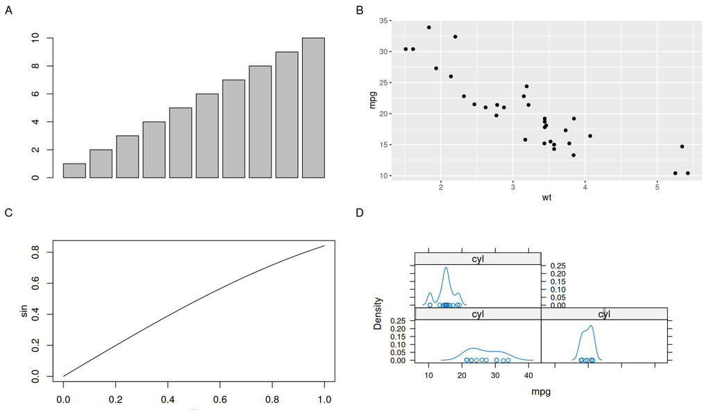

```r
library(aplot)

plot_list(~barplot(1:10), ggplot(mtcars, aes(wt, mpg)) + geom_point(),
          ~plot(sin), densityplot(~mpg | cyl, data = mtcars),
          ncol = 2, labels = LETTERS[1:4])
```

A list of already converted grobs can be arranged the same way.

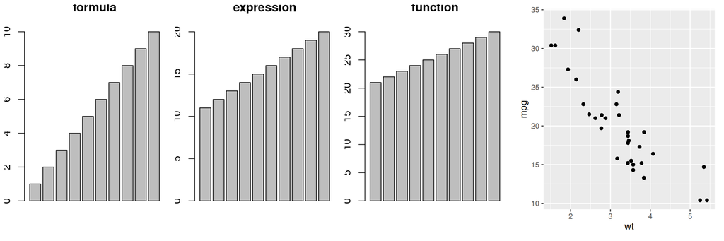

```r
plot_list(gglist = list(p1, p2, p3, p5), ncol = 4, widths = c(1, 1, 1, 1.2))
```

Two panels side by side, the same data drawn by the two graphics systems. `colorspace` provides one palette for both, so the colors match. Joining the two with `+` is patchwork’s doing: loading it registers a `+.gg` method that takes over from the one in `ggplot2`.

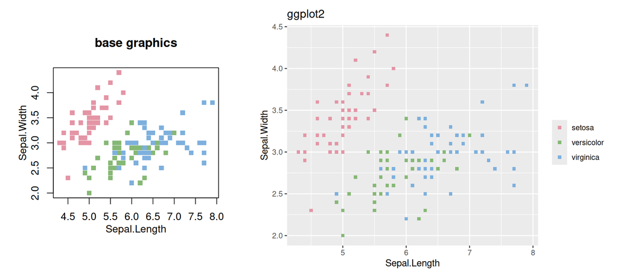

```r
library(colorspace)
library(patchwork)

col <- rainbow_hcl(3)
color <- col[iris$Species]

as.ggplot(~plot(iris$Sepal.Length, iris$Sepal.Width, col = color, pch = 15,
                xlab = "Sepal.Length", ylab = "Sepal.Width",
                main = "base graphics"),
          scale = .9) +
    ggplot(iris, aes(Sepal.Length, Sepal.Width, color = Species)) +
    geom_point(shape = 15) +
    scale_color_manual(values = col, name = "") +
    ggtitle("ggplot2")
```

## Insetting one plot into another

`ggplot2::annotation_custom()` takes a grob and places it at data coordinates, which is the simplest way to inset a converted plot.

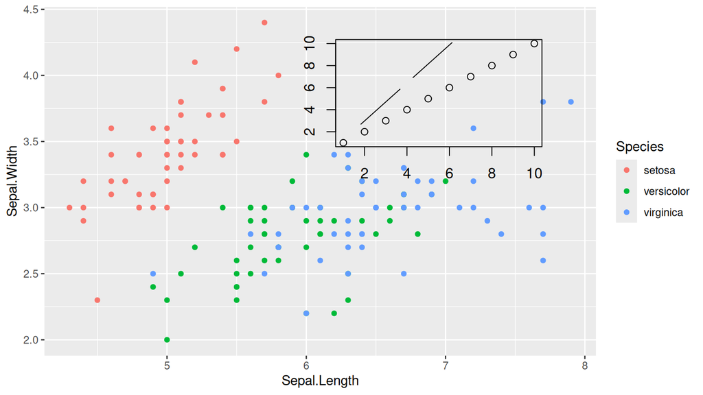

```r
ggplot(iris, aes(Sepal.Length, Sepal.Width, color = Species)) +
    geom_point() +
    annotation_custom(as.grob(recording), xmin = 6, xmax = 7.8,
                      ymin = 3.3, ymax = 4.4)
```

The inset is clipped to the panel and is positioned in data coordinates. When the position should instead be relative to the page, `grid.draw()` inside a `viewport()`, as shown above, does the job.

## Insets and subviews

Every example above ends as an ordinary `grid` object, and that is the point of the package. A plot drawn by base graphics, a `lattice` panel, a `vcd` diagram and a captured recording all become the same kind of object, so any package that can place a grob can place them.

`ggplot2::annotation_custom()` is the simplest case, and the one just shown. `aplot::insert_left()`, `insert_right()`, `insert_top()` and `insert_bottom()` attach a second plot as a marginal panel, and a converted plot is a `ggplot` object, so it goes wherever a `ggplot2` plot goes.

`ggimage::geom_subview()` puts plots inside a panel at data coordinates and sizes them with `width` and `height`. Its subviews come either from a column of the data or from the `subview` argument, and each one is converted with `as.grob()`, so that column may hold a formula, a function, a `ggplot`, a `trellis` object, a `recordedplot` or a grob. A figure that only base graphics can draw is then an inset in exactly the same way a `ggplot2` plot is. `ggimage` re-exports `as.grob()` and `as.ggplot()`, so a user of that package has the converters attached already.

Worked subview examples are in the `ggimage` documentation and vignette, which is where the feature is developed. This vignette stops at the conversion.

## Supported input classes

`as.ggplot()` accepts everything `as.grob()` does, since it converts the input and then wraps it. Methods that belong to another package are looked up when they are needed, so that package only has to be installed, not loaded.

| Input class | Produced by |
| --- | --- |
| `formula`, `expression`, `function` | any base graphics code |
| `recordedplot` | `grDevices::recordPlot()` |
| `grob` | `grid` |
| `ggplot` | `ggplot2` |
| `patchwork` | `patchwork` |
| `aplot`, `oncoplot`, `gglist` | `aplot` |
| `trellis` | `lattice` |
| `Heatmap` | `ComplexHeatmap` |
| `pheatmap` | `pheatmap` |
| `eulergram` | `eulerr` |
| `upset` | `UpSetR` |
| `meme` | `meme` |
| `tmap` | `tmap` |
| `bbplot` | `ggbio` |
| `magick-image` | `magick` |

A `gTree` has no method of its own and is handled by the `grob` method, since it inherits from `grob`.